# 218X_R1

Jordan Brinn

12/3/2020

```r
years <- 2017:2020
quarters <- 1:4
types <- c("Electric","Gas")
pge_data <- NULL

for (year in years) {
  for (quarter in quarters) {
    for (type in types) {

      filename <- paste0("PGE_",
                         year,
                         "_Q",
                         quarter,
                         "_",
                         type,
                         "UsageByZip.csv")
      if ((quarter == 4)&(year == 2020))next

      temp <- read_csv(filename)

      if(type == "Electric"){
        temp <-
          temp %>%
          mutate(TOTALKBTU = TOTALKWH * 3.412) %>%
          select(-TOTALKWH,
                 -AVERAGEKWH)

      } else {
        temp <-
          temp %>%
          mutate(TOTALKBTU = TOTALTHM * 100) %>%
          select(-TOTALTHM,
                  -AVERAGETHM)
      }
      pge_data <- rbind(pge_data,temp)


    }
  }
}
```

```r
usa_zips <-
  zctas(cb = T, progress_bar = F)

bay_county_names <-
  c(
    "Alameda",
    "Contra Costa",
    "Marin",
    "Napa",
    "San Francisco",
    "San Mateo",
    "Santa Clara",
    "Solano",
    "Sonoma"
  )

bay_counties <-
  counties("CA", cb = T, progress_bar = F) %>%
  filter(NAME %in% bay_county_names)

bay_zips <-
  usa_zips %>%
  st_centroid() %>%
  .[bay_counties, ] %>%
  st_set_geometry(NULL) %>%
  left_join(usa_zips %>% select(GEOID10)) %>%
  st_as_sf()
```

```r
bay_pge_data <-
  pge_data %>%
  filter(
    ZIPCODE %in% bay_zips$ZCTA5CE10,
    CUSTOMERCLASS %in% c("Elec- Commercial","Elec- Residential","Gas- Commercial","Gas- Residential")
  ) %>%
  group_by(
    MONTH,
    YEAR,
    CUSTOMERCLASS
  ) %>%
  summarise(
    TOTALKBTU = sum(TOTALKBTU, na.rm = T),
    TOTALCUSTOMERS = sum(TOTALCUSTOMERS, na.rm = T)
  ) %>%
  mutate(
    DATE =
      paste(
        YEAR,
        MONTH,
        "01",
        sep="-"
        #yyyy-mm-dd
        ) %>% as.Date()
  )
```

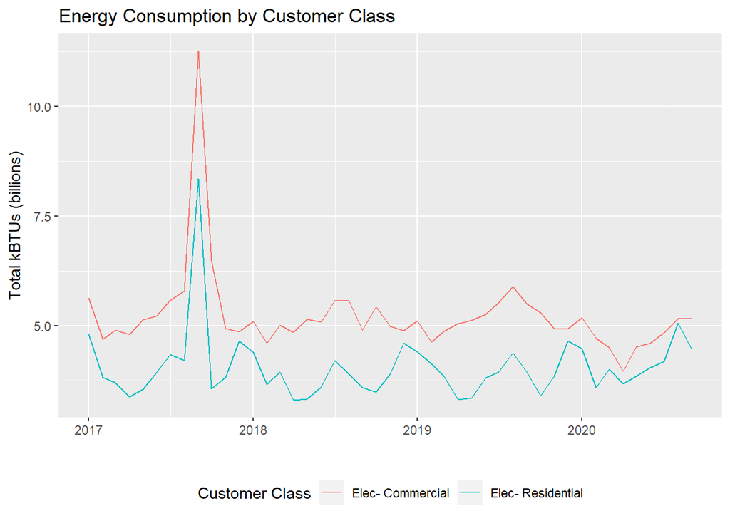

```r
bay_pge_data %>%
   filter(CUSTOMERCLASS %in% c(
    "Elec- Residential",
    "Elec- Commercial"
  )) %>%
  ggplot() +
  geom_line(
    aes(
      x = DATE,
      y = TOTALKBTU/1e9,
      color = CUSTOMERCLASS
    )
  ) +
labs(
  x = "",
  y = "Total kBTUs (billions)",
  title = "Energy Consumption by Customer Class",
  color = "Customer Class"
) +
  theme(
    legend.position = "bottom"
  )
```

Looking at the charts of residential and commercial electricity and gas usage for Q1 2017 to Q3 2020 below, there seems to be a slight increase in overall residential energy consumption and a slight decrease in overall commercial energy consumption for Q2 and Q3 between 2019 and 2020. This trend is likely due to behavioral changes (increased working from home) due to the COVID-19 pandemic which began to impact the United States at the end of Q1 2020.

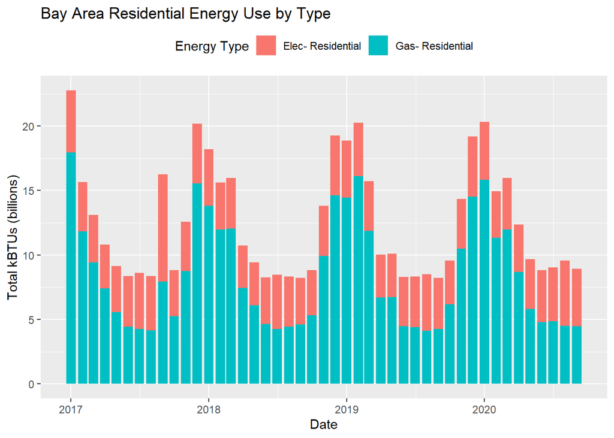

```r
#stacked bar chart of Residential Electricity and Gas Usage
bay_pge_data %>%
   filter(CUSTOMERCLASS %in% c(
    "Elec- Residential" ,
    "Gas- Residential"
  )) %>%
  ggplot() +
  geom_bar(
    aes(
      x = DATE,
      y = TOTALKBTU/1e9,
      fill = CUSTOMERCLASS
    ),
    stat = "identity",
    position = "stack"
  ) +
labs(
  x = "Date",
  y = "Total kBTUs (billions)",
  title = "Bay Area Residential Energy Use by Type",
  color = "Customer Class" ,
  fill = "Energy Type"
) +
  theme(
    legend.position = "top"
  )
```

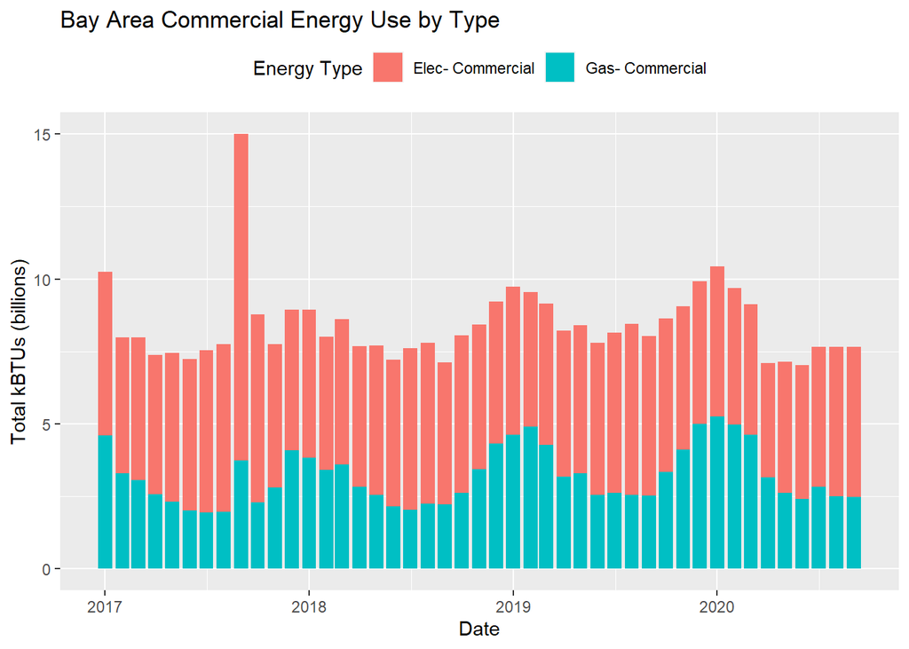

```r
#stacked bar chart of Commerical Electricity and Gas Usage
bay_pge_data %>%
   filter(CUSTOMERCLASS %in% c(
    "Elec- Commercial" ,
    "Gas- Commercial"
  )) %>%
  ggplot() +
  geom_bar(
    aes(
      x = DATE,
      y = TOTALKBTU/1e9,
      fill = CUSTOMERCLASS
    ),
    stat = "identity",
    position = "stack"
  ) +
labs(
  x = "Date",
  y = "Total kBTUs (billions)",
  title = "Bay Area Commercial Energy Use by Type",
  color = "Customer Class" ,
  fill = "Energy Type"
) +
  theme(
    legend.position = "top"
  )
```

```r
bay_pge_change <-
  pge_data %>%
  filter (
    CUSTOMERCLASS %in% c("Elec- Residential"),
    YEAR %in% 2019:2020,
    MONTH %in% 4:6
  ) %>%
  group_by(ZIPCODE, CUSTOMERCLASS, YEAR) %>%
  summarize(SPRINGKBTU = mean(TOTALKBTU, na.rm = T)) %>%
  unite( #paste together multiple columns into one
    key,
    c(CUSTOMERCLASS,YEAR),
    sep="- "
  ) %>%
  pivot_wider(
    names_from = key, #makes the values in key the name of the columns
    values_from = SPRINGKBTU
  ) %>%
  mutate(
    elec_res_change =
      (`Elec- Residential- 2020`/ `Elec- Residential- 2019` - 1)*100
  ) %>%
  left_join(
    bay_zips %>%
      transmute(ZIPCODE = ZCTA5CE10 %>% as.numeric())
  )  %>%
  st_as_sf()
```

```r
elec_res_change <-
  bay_pge_change %>%
  filter(
    is.finite(elec_res_change),
    elec_res_change > -100
  )

abs_max <-
  elec_res_change %>%
  pull(elec_res_change) %>%
  range() %>%
  abs() %>%
  max()

elec_res_change_pal <- colorBin(
  palette = "PiYG",
  bins = c(min(elec_res_change$elec_res_change),-30,-10,-5,0,5,10,15,20,40,max(elec_res_change$elec_res_change, na.rm = T))
)

leaflet() %>%
  addProviderTiles(providers$CartoDB.Positron) %>%
  addPolygons(
    data = elec_res_change,
    fillColor = ~elec_res_change_pal(elec_res_change),
    color = "white",
    fillOpacity = 0.75,
    weight = 1,
    label = ~paste0(
      round(elec_res_change),
      " % change in kBTU total in ",
      ZIPCODE
    ),
    highlightOptions = highlightOptions(
      weight = 2
    )
  ) %>%
  addLegend(
    data = elec_res_change,
    pal = elec_res_change_pal,
    values = ~elec_res_change,
    title = "% Change kBTU<br>Residential Electricity"
  )
```

[interactive chart not shown]

Map of percent changes (2020 consumption as a percentage of 2019 consumption) in residential electricity consumption in the Bay Area for months April-June for each year.

As expected based on the energy consumption charts earlier in the report, many zip codes in the Bay Area have experienced an increased in April-June residential electricity consumption in 2020 compared to 2019 usage. However, this increase in usage appears to generally decrease in magnitude and even flip to a decrease in usage by zipcode moving from west to east within the Bay Area with the primary exception of some zipcodes in the northwest of Marin County. This trend could possibly be due to people moving out of urban areas in the peninsula as a result of the pandemic.